# Herbivory survey analysis

Load the Sun Shade header file:

```r
source("./_sun_shade_header.R")
```

Load the data:

```r
survey <- read.table(file="./data/source_site_traits/site_herbivory_final.txt",header=T)
```

### Plots

Plotting the data for A3 Fig. S1:

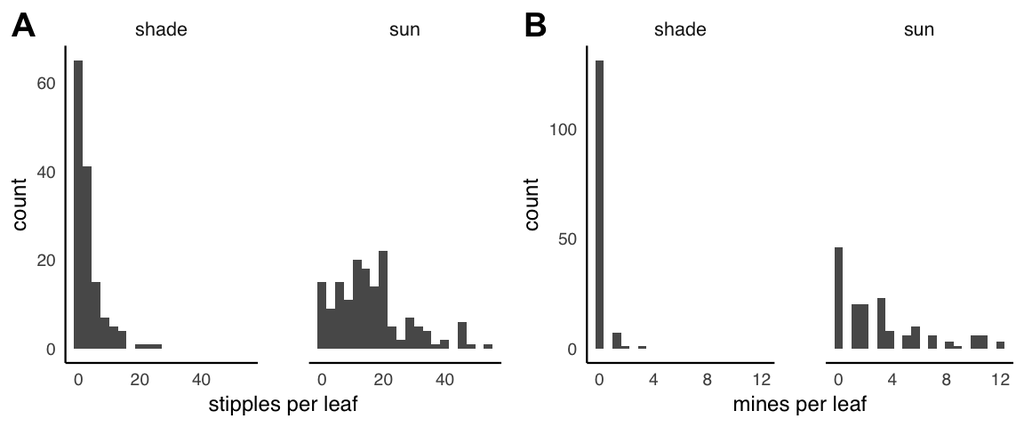

```r
fS1a <- ggplot(survey,aes(x = stipples)) + geom_histogram(bins = 20) + facet_wrap(~ site_type) +
  theme_pth1() + xlab("stipples per leaf")
fS1b <- ggplot(survey,aes(x = mines)) + geom_histogram(bins = 20) + facet_wrap(~ site_type) +
  theme_pth1() + xlab("mines per leaf")

# Appendix 3: Fig. S1
# pdf(file = "./Appendix_S3/A3_figS1.pdf", width = 6, height = 2.5, onefile = F)
#   ggarrange(plotlist = list(fS1a, fS1b), nrow = 1, ncol = 2, labels = c("A","B"))
# dev.off()
ggarrange(plotlist = list(fS1a, fS1b), nrow = 1, ncol = 2, labels = c("A","B"))
```

Plot variance/mean ratios for stipple and mine data from herbivory survey (A3 Fig. S2):

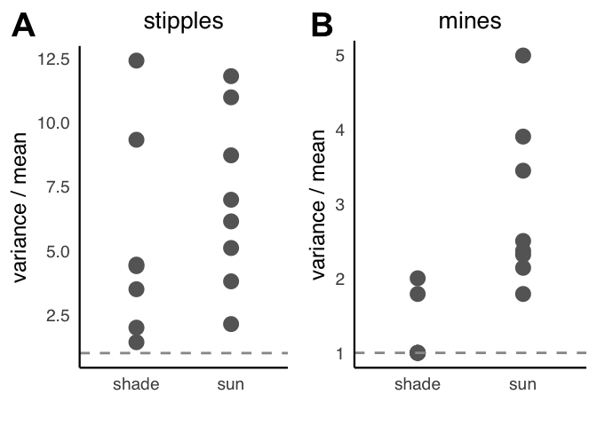

```r
survey3 <- dplyr::group_by(survey, site_type, site_id) %>% summarise(mu_stip = mean(stipples),
                                                                     var_stip = var(stipples),
                                                                     mu_mines = mean(mines),
                                                                     var_mines = var(mines))

fano1 <- ggplot(survey3, aes(y = var_stip/mu_stip, x = site_type)) +
  geom_point(size = 2.5, col = "gray40") +
  theme_pth1() + ggtitle("stipples") + theme(plot.title = element_text(size = 10, hjust = 0.5)) +
  geom_hline(yintercept = 1, col = "gray60", lty = 2) +
  xlab("") +
  ylab("variance / mean")

fano2 <- ggplot(survey3, aes(y = var_mines/mu_mines, x = site_type)) +
  geom_point(size = 2.5, col = "gray40") +
  theme_pth1() + ggtitle("mines") + theme(plot.title = element_text(size = 10, hjust = 0.5)) +
  geom_hline(yintercept = 1, col = "gray60", lty = 2) +
  xlab("") +
  ylab("variance / mean")

# pdf(file = "./Appendix_S3/A3_figS2.pdf", width = 4, height = 2.5)
#   ggarrange(plotlist = list(fano1, fano2), nrow = 1,ncol = 2, labels = c("A","B"))
# dev.off()

ggarrange(plotlist = list(fano1, fano2), nrow = 1,ncol = 2, labels = c("A","B"))
```

Plotting the data that went into Fig. 1A:

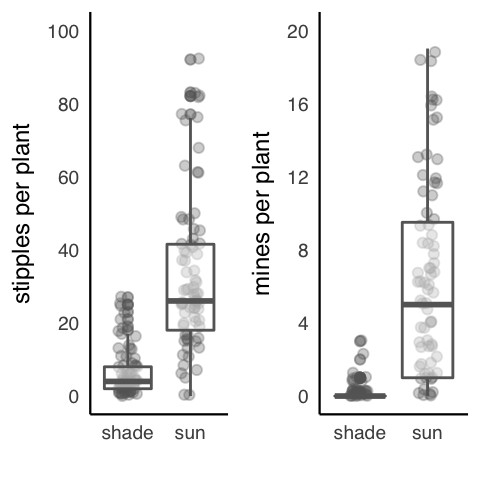

```r
survey2 <- dplyr::group_by(survey, site_type, stem_id) %>% summarise(n_stips = sum(stipples), n_mines = sum(mines))

stip1 <- ggplot(survey2, aes(x = site_type, y = n_stips)) +
  geom_jitter(width = 0.15, alpha = 0.3, col = "gray40") +
  geom_boxplot(alpha = 0.5, col = "gray40") + theme_pth1() +
  scale_y_continuous(limits = c(0,100), breaks = seq(0,100,20)) + xlab("") + ylab("stipples per plant")

mine1 <- ggplot(survey2, aes(x = site_type, y = n_mines)) +
  geom_jitter(width = 0.15, alpha = 0.3, col = "gray40") +
  geom_boxplot(alpha = 0.5, col = "gray40") + theme_pth1() +
  scale_y_continuous(limits = c(0,20), breaks = seq(0,20,4)) + xlab("") + ylab("mines per plant")

ggarrange(plotlist = list(stip1, mine1))
```

### Models

#### Stipples

For illustrative purposes, below we run through the analyses described in Part 1 of Appendix S3, where we fit Poisson-only vs. ZI-Poisson and then factor-specific ZI parameters. We include fits estimated under NB as well. For these purposes, we removed the `area` term to improve model convergence of the habitat-specific ZI-Poisson model (below). In the section that follows, we re-fit and re-compare all models *including* this term.

Running Poisson-only and comparing to ZI-Poisson:

```r
POIS.stip0 <- glmmTMB(stipples ~ site_type + (1|site_id) + (1|stem_id),
                     data = survey,
                     family = poisson)

POIS.stip1 <- glmmTMB(stipples ~ site_type + (1|site_id) + (1|stem_id),
                    zi = ~ 1,
                    data = survey,
                    family = poisson)

POIS.stip2 <- glmmTMB(stipples ~ site_type + (1|site_id) + (1|stem_id),
                      zi = ~ site_type,
                      data = survey,
                      family = poisson)
```

Generate simulations and make predictive distribution plots from MLE fits:

```r
set.seed(12345)

POIS.stip0.sim <- simulate(POIS.stip0,  nsim = 1000)
POIS.stip1.sim <- simulate(POIS.stip1,  nsim = 1000)
POIS.stip2.sim <- simulate(POIS.stip2,  nsim = 1000)

survey.stip.pp0 <- pp.plots(thesim = POIS.stip0.sim, thedat = survey, thefact = 'site_type', theresponse = 'stipples')
survey.stip.pp1 <- pp.plots(thesim = POIS.stip1.sim, thedat = survey, thefact = 'site_type', theresponse = 'stipples')
survey.stip.pp2 <- pp.plots(thesim = POIS.stip2.sim, thedat = survey, thefact = 'site_type', theresponse = 'stipples')
```

Generate plot for comparisons to include as A3 Fig. S3:

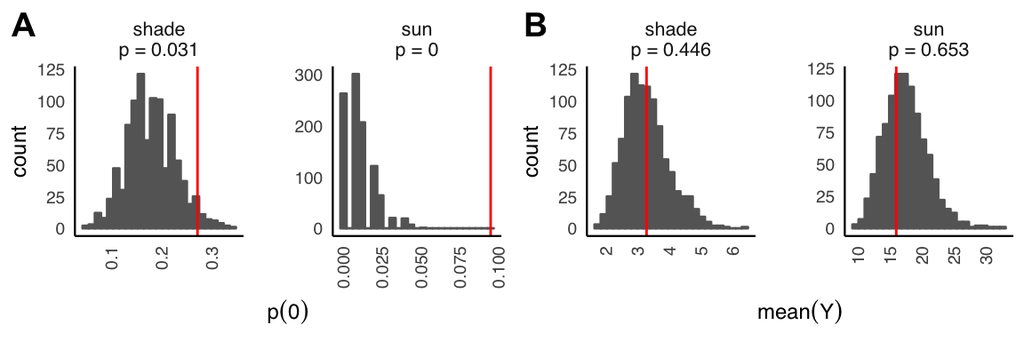

```r
# pdf(file = "./Appendix_S3/POIS.stip0.pp.pdf", width = 6, height = 2, onefile = F)
#   survey.stip.pp0$plots
# dev.off()
survey.stip.pp0$plots
```

Calculate max(Y) distribution and p-value:

```r
survey.stip.max0 <- pp.max(sim1 = POIS.stip0.sim, dat1 = survey, fact1 = 'site_type', response1 = 'stipples')
survey.stip.max1 <- pp.max(sim1 = POIS.stip1.sim, dat1 = survey, fact1 = 'site_type', response1 = 'stipples')
survey.stip.max2 <- pp.max(sim1 = POIS.stip2.sim, dat1 = survey, fact1 = 'site_type', response1 = 'stipples')

#ggarrange(plotlist = list(survey.stip.max0$plot,survey.stip.max1$plot,survey.stip.max2$plot),ncol = 3)
```

Generate A3 Fig. S4:

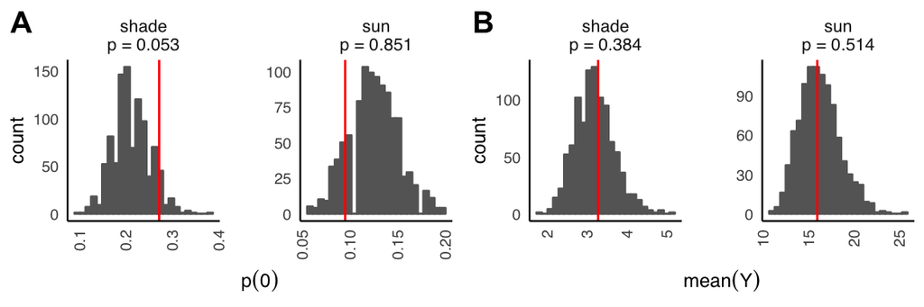

```r
# pdf(file = "./Appendix_S3/POIS.stip1.pp.pdf", width = 6, height = 2, onefile = F)
#   survey.stip.pp1$plots
# dev.off()

survey.stip.pp1$plots
```

Generate A3 Fig. S5:

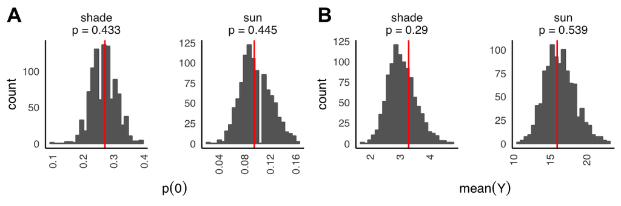

```r
# pdf(file = "./Appendix_S3/POIS.stip2.pp.pdf", width = 6, height = 2, onefile = F)
#   survey.stip.pp2$plots
# dev.off()

survey.stip.pp2$plots
```

Try also to plot additional test statistic that might help reveal how Poisson fails to fit at the upper range, particularly for shaded sites (A3 Fig. S6):

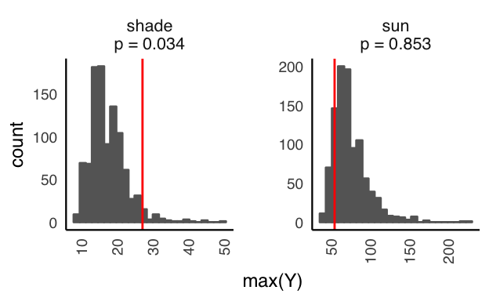

```r
POIS.stip0.max <- pp.max(sim1 = POIS.stip0.sim, dat1 = survey,
                         fact1 = 'site_type', response1 = 'stipples')
POIS.stip1.max <- pp.max(sim1 = POIS.stip1.sim, dat1 = survey,
                         fact1 = 'site_type', response1 = 'stipples')
POIS.stip2.max <- pp.max(sim1 = POIS.stip2.sim, dat1 = survey,
                         fact1 = 'site_type', response1 = 'stipples')
# ggarrange(plotlist = list(POIS.stip0.max$plot,POIS.stip1.max$plot,POIS.stip2.max$plot),ncol = 3)

# pdf(file = "./Appendix_S3/POIS.stip.2.max.pdf", width = 3.25, height = 2, onefile = F)
#   print(POIS.stip2.max$plot + xlab("max(Y)"))
# dev.off()
print(POIS.stip2.max$plot + xlab("max(Y)"))
```

Now run Negative Binomial models with and without ZI and dispersion terms:

```r
ZINB.stip0  <- glmmTMB(stipples ~ site_type + (1|site_id) + (1|stem_id),
                     data = survey,
                     family = nbinom2)

ZINB.stip1  <- glmmTMB(stipples ~ site_type + (1|site_id) + (1|stem_id),
                     zi = ~ 1,
                     data = survey,
                     family = nbinom2)

ZINB.stip2  <- glmmTMB(stipples ~ site_type + (1|site_id) + (1|stem_id),
                     zi = ~ site_type,
                     data = survey,
                     family = nbinom2)

ZINB.stip3  <- glmmTMB(stipples ~ site_type + (1|site_id) + (1|stem_id),
                     zi = ~ 1,
                     dispformula = ~ 0 + site_type,
                     data = survey,
                     family = nbinom2)

ZINB.stip4  <- glmmTMB(stipples ~ site_type + (1|site_id) + (1|stem_id),
                     zi = ~ site_type,
                     dispformula = ~ 0 + site_type,
                     data = survey,
                     family = nbinom2)
# errors produced by these models above are normal.
# See https://cran.r-project.org/web/packages/glmmTMB/vignettes/troubleshooting.html
```

Output all model comparisons via $\text{AIC}_c$:

```r
AICs <- ICtab(POIS.stip0,POIS.stip1,POIS.stip2,ZINB.stip0,
              ZINB.stip1,ZINB.stip2,ZINB.stip3,ZINB.stip4, type = 'AICc')
print(AICs)
```

```
##            dAICc df
## ZINB.stip3   0.0 7
## ZINB.stip4   1.8 8
## ZINB.stip2  19.3 7
## ZINB.stip1  20.6 6
## ZINB.stip0  63.3 5
## POIS.stip2  72.5 6
## POIS.stip1  74.3 5
## POIS.stip0 204.0 4
```

Output all model test statistics and generate table:

```r
AICs2 <- data.frame(model = attr(AICs, 'row.names'), dAICc = AICs[[1]], df = AICs[[2]])
# write.table(AICs2, file = "./model_output/AICs.txt",sep = "\t")
```

Generate simulations for sub-optimal ZINB models:

```r
survey.stip.sim0  <- simulate(ZINB.stip0,  nsim = 1000)
survey.stip.sim1  <- simulate(ZINB.stip1,  nsim = 1000)
survey.stip.sim2  <- simulate(ZINB.stip2,  nsim = 1000)
survey.stip.sim4  <- simulate(ZINB.stip4,  nsim = 1000)

# calcualte pp.plots for each:
ZINB.pp0 <- pp.plots(thesim = survey.stip.sim0, thedat = survey,
                     thefact = 'site_type', theresponse = 'stipples')
ZINB.pp1 <- pp.plots(thesim = survey.stip.sim1, thedat = survey,
                     thefact = 'site_type', theresponse = 'stipples')
ZINB.pp2 <- pp.plots(thesim = survey.stip.sim2, thedat = survey,
                     thefact = 'site_type', theresponse = 'stipples')
ZINB.pp4 <- pp.plots(thesim = survey.stip.sim4, thedat = survey,
                     thefact = 'site_type', theresponse = 'stipples')

#ggarrange(plotlist = list(ZINB.pp0$plots,ZINB.pp1$plots,ZINB.pp2$plots,ZINB.pp4$plots))
```

Now for the maximum values:

```r
ZINB.pp.max0 <- pp.max(sim1 = survey.stip.sim0, dat1 = survey,
                       fact1 = 'site_type', response1 = 'stipples')
ZINB.pp.max1 <- pp.max(sim1 = survey.stip.sim1, dat1 = survey,
                       fact1 = 'site_type', response1 = 'stipples')
ZINB.pp.max2 <- pp.max(sim1 = survey.stip.sim2, dat1 = survey,
                       fact1 = 'site_type', response1 = 'stipples')
ZINB.pp.max4 <- pp.max(sim1 = survey.stip.sim4, dat1 = survey,
                       fact1 = 'site_type', response1 = 'stipples')

#ggarrange(plotlist = list(ZINB.pp.max0$plot,ZINB.pp.max1$plot,ZINB.pp.max2$plot,ZINB.pp.max4$plot))
```

Output coefficient estimates for best model:

```r
survey.stip.bm <- ZINB.stip3
ci_stips <- confint(survey.stip.bm)
coef_stips <- do.call(rbind,summary(survey.stip.bm)$coef)
round(ci_stips,2)
```

```
##                                  2.5 % 97.5 % Estimate
## cond.(Intercept)                  0.82   1.44     1.13
## cond.site_typesun                 1.22   1.98     1.60
## cond.Std.Dev.stem_id.(Intercept)  0.34   0.56     0.43
## cond.Std.Dev.site_id.(Intercept)  0.15   0.50     0.28
## zi.zi~(Intercept)                -2.82  -1.78    -2.30
## sigma                             0.81   2.40     1.40
## sigma                             6.90  24.30    12.95
```

Simulate best stipple model:

```r
set.seed(12345)
survey.stip.sim  <- simulate(survey.stip.bm,  nsim = 1000)
```

Predictive model check for $p(0)_i$ and $\mu_i$:

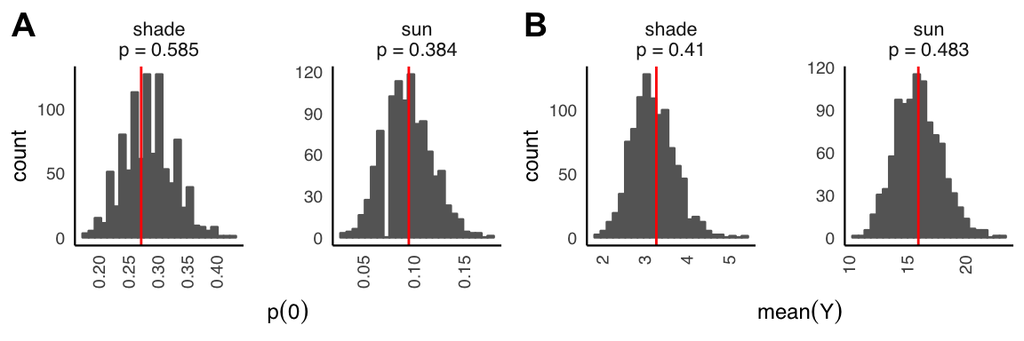

```r
survey.stip.pp <- pp.plots(thesim = survey.stip.sim, thedat = survey, thefact = 'site_type', theresponse = 'stipples')

# pdf(file = "./Appendix_S3/survey_stip_pp.pdf", width = 6, height = 2, onefile = F)
#   print(survey.stip.pp$plots)
# dev.off()

print(survey.stip.pp$plots)
```

Additional check on max(Y) to see that NB fixed problem for shade sites:

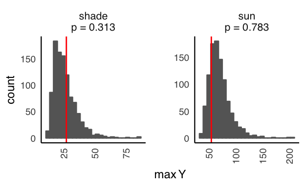

```r
survey.stip.max <- pp.max(sim1 = survey.stip.sim, dat1 = survey, fact1 = 'site_type', response1 = 'stipples')

# pdf(file = "./Appendix_S3/survey_stip_max.pdf", width = 3.25, height = 2, onefile = F)
#   print(survey.stip.max$plot)
# dev.off()

print(survey.stip.max$plot)
```

Print summary of test statistics:

```r
print(survey.stip.pp$means)
```

```
## # A tibble: 2 x 4
##     fact       mu2     lower     upper
##   <fctr>     <dbl>     <dbl>     <dbl>
## 1  shade  3.199636  2.313929  4.264464
## 2    sun 15.952006 12.430222 19.848259
```

```r
print(survey.stip.pp$p0)
```

```
## # A tibble: 2 x 4
##                fact1         p0      lower     upper
##               <fctr>      <dbl>      <dbl>     <dbl>
## 1 "shade\np = 0.585" 0.28459286 0.20714286 0.3642857
## 2   "sun\np = 0.384" 0.09331013 0.05063291 0.1392405
```

```r
print(survey.stip.pp$intensity)
```

```
## # A tibble: 2 x 4
##     fact       mu2     lower     upper
##   <fctr>     <dbl>     <dbl>     <dbl>
## 1  shade  4.464732  3.448553  5.692363
## 2    sun 17.593301 13.913986 22.025134
```

Combined plot output of best ZINB model (A3 Fig. S7):

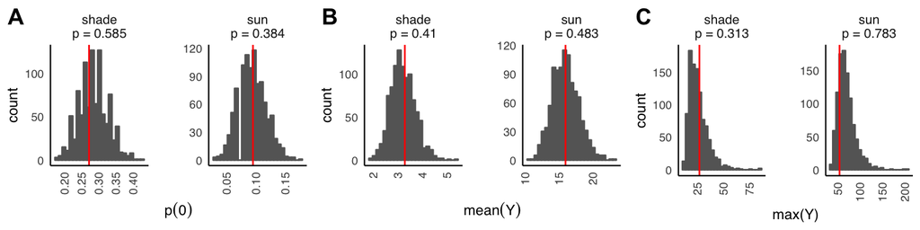

```r
survey.stip.max$plot <- survey.stip.max$plot + xlab("max(Y)")
# pdf(file = "./Appendix_S3/pp_stips_best_mod.pdf", width = 8, height = 2, onefile = F)
#   ggarrange(plotlist = list(survey.stip.pp$plots,survey.stip.max$plot), labels = c('','C'), align = 'hv', widths = c(2.15,1))
# dev.off()
ggarrange(plotlist = list(survey.stip.pp$plots,survey.stip.max$plot), labels = c('','C'), align = 'hv', widths = c(2.15,1))
```

#### Re-fitting all models with `area` term

Including the `area` term results in convergence issues with the habitat-specific ZI-Poisson model (`POIS.stip2`) but does not affect the optimisation of any of the other models. Below we report model comparisons among all of the above models re-fit with `area` except `POIS.stip2`.

First, re-fit:

```r
# re-fit all models with area term:
survey <- survey[complete.cases(survey),] # remove all rows with any 'NA' elements (excludes one additional row with NA leaf area)

POIS.stip0b <- glmmTMB(stipples ~ area + site_type + (1|site_id) + (1|stem_id),
                     data = survey,
                     family = poisson)

POIS.stip1b <- glmmTMB(stipples ~ area + site_type + (1|site_id) + (1|stem_id),
                    zi = ~ 1,
                    data = survey,
                    family = poisson)
# errors produced by these models above are normal.
# See https://cran.r-project.org/web/packages/glmmTMB/vignettes/troubleshooting.html

POIS.stip2b <- glmmTMB(stipples ~ area + site_type + (1|site_id) + (1|stem_id),
                      zi = ~ site_type,
                      data = survey,
                      family = poisson) # this model has convergence problems!

## ZI-Negative Binomial models
ZINB.stip0b  <- glmmTMB(stipples ~ area + site_type + (1|site_id) + (1|stem_id),
                     data = survey,
                     family = nbinom2)

ZINB.stip1b  <- glmmTMB(stipples ~ area + site_type + (1|site_id) + (1|stem_id),
                     zi = ~ 1,
                     data = survey,
                     family = nbinom2)

ZINB.stip2b  <- glmmTMB(stipples ~ area + site_type + (1|site_id) + (1|stem_id),
                     zi = ~ site_type,
                     data = survey,
                     family = nbinom2)

ZINB.stip3b  <- glmmTMB(stipples ~ area + site_type + (1|site_id) + (1|stem_id),
                     zi = ~ 1,
                     dispformula = ~ 0 + site_type,
                     data = survey,
                     family = nbinom2)

ZINB.stip4b  <- glmmTMB(stipples ~ area + site_type + (1|site_id) + (1|stem_id),
                     zi = ~ site_type,
                     dispformula = ~ 0 + site_type,
                     data = survey,
                     family = nbinom2)
```

Re-running model comparisons via $\text{AIC}_c$:

```r
AICsb <- ICtab(POIS.stip0b,POIS.stip1b,POIS.stip2b,
               ZINB.stip0b,ZINB.stip1b,ZINB.stip2b,ZINB.stip3b,ZINB.stip4b, type = 'AICc')
print(AICsb)
```

```
##             dAICc df
## ZINB.stip3b   0.0 8
## ZINB.stip4b   1.7 9
## ZINB.stip2b  22.0 8
## ZINB.stip1b  22.8 7
## ZINB.stip0b  58.8 6
## POIS.stip1b  63.2 6
## POIS.stip0b 164.5 5
## POIS.stip2b    NA 7
```

Output coefficient estimates for best model (still `ZINB.stip3`, now labeled `ZINB.stip3b` with `area` term):

```r
survey.stip.bm_2 <- ZINB.stip3b
ci_stips <- confint(survey.stip.bm_2)
coef_stips <- do.call(rbind,summary(survey.stip.bm_2)$coef)
round(ci_stips,2)
```

```
##                                  2.5 % 97.5 % Estimate
## cond.(Intercept)                  0.41   1.18     0.79
## cond.area                         0.00   0.02     0.01
## cond.site_typesun                 1.23   2.04     1.63
## cond.Std.Dev.stem_id.(Intercept)  0.34   0.56     0.44
## cond.Std.Dev.site_id.(Intercept)  0.18   0.54     0.31
## zi.zi~(Intercept)                -2.83  -1.79    -2.31
## sigma                             0.84   2.48     1.45
## sigma                             7.86  34.08    16.36
```

Simulate best model and output test statistics:

```r
set.seed(12345)
survey.stip.sim_2  <- simulate(survey.stip.bm_2,  nsim = 1000)
survey.stip.pp_2 <- pp.plots(thesim = survey.stip.sim_2, thedat = survey, thefact = 'site_type', theresponse = 'stipples')
survey.stip.max_2 <- pp.max(sim1 = survey.stip.sim_2, dat1 = survey, fact1 = 'site_type', response1 = 'stipples')
```

Plot predictive distributions of test statistics:

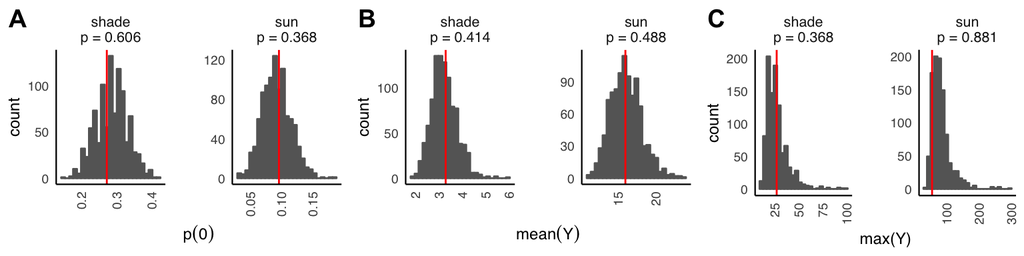

```r
survey.stip.max_2$plot <- survey.stip.max_2$plot + xlab("max(Y)")
ggarrange(plotlist = list(survey.stip.pp_2$plots,survey.stip.max_2$plot),
          labels = c('','C'), align = 'hv', widths = c(2.15,1))
```

Generate predicted responses for main text:

```r
print(survey.stip.pp_2$means)
```

```
## # A tibble: 2 x 4
##     fact       mu2     lower     upper
##   <fctr>     <dbl>     <dbl>     <dbl>
## 1  shade  3.214207  2.285536  4.285893
## 2    sun 16.051592 12.488535 20.373726
```

```r
print(survey.stip.pp_2$p0)
```

```
## # A tibble: 2 x 4
##                fact1         p0      lower     upper
##               <fctr>      <dbl>      <dbl>     <dbl>
## 1 "shade\np = 0.606" 0.28548571 0.20000000 0.3714286
## 2   "sun\np = 0.368" 0.09148408 0.05095541 0.1401274
```

```r
print(survey.stip.pp_2$intensity)
```

```
## # A tibble: 2 x 4
##     fact       mu2     lower     upper
##   <fctr>     <dbl>     <dbl>     <dbl>
## 1  shade  4.487483  3.410419  5.845865
## 2    sun 17.667126 13.796943 22.553567
```

Note that intensity was not reported in text. This is the average stipple count *given that the leaf was damaged*, rather than the average stipple number across all sampled leaves (i.e., including zeros).

### Models of Leaf mines from herbivory survey

Run the models, *with* leaf area in all cases:

```r
## POISSON MODELS
POIS.mines0  <- glmmTMB(mines ~ site_type + area + (1|site_id) + (1|stem_id),
                     #zi = ~1,
                     data = survey,
                     family = poisson)

POIS.mines1  <- glmmTMB(mines ~ site_type + area + (1|site_id) + (1|stem_id),
                     zi = ~1,
                     data = survey,
                     family = poisson)

POIS.mines2  <- glmmTMB(mines ~ site_type + area + (1|site_id) + (1|stem_id),
                     zi = ~site_type,
                     data = survey,
                     family = poisson)

## NEGATIVE BINOMIAL MODELS
ZINB.mines0  <- glmmTMB(mines ~ site_type + area + (1|site_id) + (1|stem_id),
                     #zi = ~1,
                     #dispformula = ~1,
                     data = survey,
                     family = nbinom2)

ZINB.mines1  <- glmmTMB(mines ~ site_type + area + (1|site_id) + (1|stem_id),
                     zi = ~1,
                     #dispformula = ~1,
                     data = survey,
                     family = nbinom2)

ZINB.mines2  <- glmmTMB(mines ~ site_type + area + (1|site_id) + (1|stem_id),
                     zi = ~ site_type,
                     #dispformula = ~0 + site_type,
                     data = survey,
                     family = nbinom2)

ZINB.mines3  <- glmmTMB(mines ~ site_type + area + (1|site_id) + (1|stem_id),
                     zi = ~ 1,
                     dispformula = ~ site_type,
                     data = survey,
                     family = nbinom2)

ZINB.mines4  <- glmmTMB(mines ~ site_type + area + (1|site_id) + (1|stem_id),
                     zi = ~ site_type,
                     dispformula = ~ site_type,
                     data = survey,
                     family = nbinom2) # convergence problems; not considered further.
```

Output model comparisons via $\text{AIC}_c$:

```r
ICtab(POIS.mines0,POIS.mines1,POIS.mines2,
      ZINB.mines0,ZINB.mines1,ZINB.mines2,ZINB.mines3,ZINB.mines4, type = 'AICc')
```

```
##             dAICc df
## ZINB.mines3  0.0  8
## ZINB.mines2  1.1  8
## ZINB.mines1  1.4  7
## ZINB.mines4  2.1  9
## ZINB.mines0  8.2  6
## POIS.mines2 12.6  7
## POIS.mines1 13.3  6
## POIS.mines0 38.1  5
```

Output coefficient estimate for best model:

```r
# best model
survey.mine.bm <- ZINB.mines3
ci_mines <- confint(survey.mine.bm)
coef_mines <- do.call(rbind,summary(survey.mine.bm)$coef)
round(ci_mines,2)
```

```
##                                  2.5 % 97.5 % Estimate
## cond.(Intercept)                 -4.27  -2.25    -3.26
## cond.site_typesun                 2.73   4.77     3.75
## cond.area                         0.01   0.03     0.02
## cond.Std.Dev.stem_id.(Intercept)  0.00  14.71     0.13
## cond.Std.Dev.site_id.(Intercept)  0.39   1.08     0.65
## zi.zi~(Intercept)                -2.40  -1.03    -1.71
## sigma                             0.04   1.38     0.24
## sigma                             2.45 118.06    17.02
```

Simulate best model for mines:

```r
set.seed(12345)
survey.mine.sim  <- simulate(survey.mine.bm,  nsim = 1000)
```

Predictive model check for $p(0)_i$ and $\mu_i$:

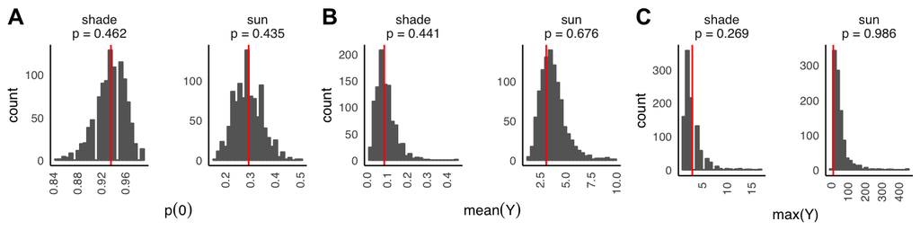

```r
survey.mine.pp <- pp.plots(thesim = survey.mine.sim, thedat = survey,
                           thefact = 'site_type', theresponse = 'mines')
survey.mine.max <- pp.max(sim1 = survey.mine.sim, dat1 = survey,
                          fact1 = 'site_type', response1 = 'mines')

survey.mine.max$plot <- survey.mine.max$plot + xlab("max(Y)")

ggarrange(plotlist = list(survey.mine.pp$plots,survey.mine.max$plot),
          labels = c('','C'), align = 'hv', widths = c(2.15,1))
```

Predictive model checks for best-ranked Poisson (but worse than ZINB via AICc) model:

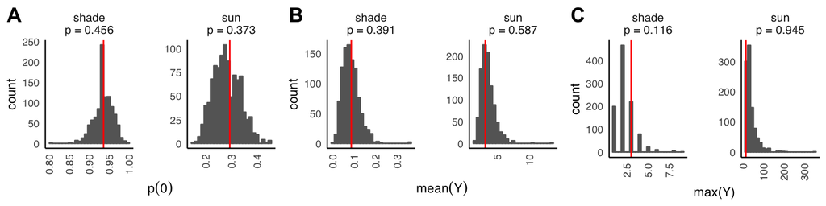

```r
survey.mine.sim.pois  <- simulate(POIS.mines2,  nsim = 1000)
survey.mine.pp.pois <- pp.plots(thesim = survey.mine.sim.pois, thedat = survey,
                                thefact = 'site_type', theresponse = 'mines')
survey.mine.max.pois <- pp.max(sim1 = survey.mine.sim.pois, dat1 = survey,
                               fact1 = 'site_type', response1 = 'mines')

survey.mine.max.pois$plot <- survey.mine.max.pois$plot + xlab("max(Y)")

ggarrange(plotlist = list(survey.mine.pp.pois$plots,survey.mine.max.pois$plot),
          labels = c('','C'), align = 'hv', widths = c(2.15,1))
```

In many ways, the ZI-Poisson (ZIP) model (`POIS.mines2`) fits as well if not slightly better via max(Y) than the best ZINB model (`ZINB.mines3`) (for sun habitats, $p_{T_{max}}^{ZIP} = 0.945; p_{T_{max}}^{ZINB} = 0.986$). However, judged by $\text{AIC}_c$, the ZINB version with habitat-specific dispersion is a better overall model ($\Delta \text{AIC}_c = -12.6$). Both models produce very similar predicted responses in terms of means and prevalence. Let’s directly compare, first with the best ZINB model:

```r
print(survey.mine.pp$means)
```

```
## # A tibble: 2 x 4
##     fact      mu2      lower     upper
##   <fctr>    <dbl>      <dbl>     <dbl>
## 1  shade 0.091450 0.02857143 0.2071429
## 2    sun 3.740911 2.01863057 6.7078025
```

```r
print(survey.mine.pp$p0)
```

```
## # A tibble: 2 x 4
##                fact1        p0     lower     upper
##               <fctr>     <dbl>     <dbl>     <dbl>
## 1 "shade\np = 0.462" 0.9352214 0.8785714 0.9785714
## 2   "sun\np = 0.435" 0.2903312 0.1910828 0.4076433
```

Now for the ZIP model:

```r
print(survey.mine.pp.pois$means)
```

```
## # A tibble: 2 x 4
##     fact        mu2      lower     upper
##   <fctr>      <dbl>      <dbl>     <dbl>
## 1  shade 0.08357143 0.02857143 0.1642857
## 2    sun 3.48992994 2.01894904 6.0511146
```

```r
print(survey.mine.pp.pois$p0)
```

```
## # A tibble: 2 x 4
##                fact1       p0     lower     upper
##               <fctr>    <dbl>     <dbl>     <dbl>
## 1 "shade\np = 0.456" 0.935400 0.8857143 0.9714286
## 2   "sun\np = 0.373" 0.280758 0.1910828 0.3821656
```

In the end, the differences are operationally indistinguishable for the main response variables we are interested in (prevalence and overall mean abundance of damage). Thus, we will defer to the $\Delta \text{AIC}_c$ result for determining which model to report in Table 1 of the main text (`ZINB.mines3`).

### Outputting model coefficients

Below we output model coefficients reported in Table 1 of the main text:

```r
OUTDIR <- "./model_output/"
write.table(round(ci_stips,2), file = paste0(OUTDIR,"survey_stips.txt"), sep = '\t')
write.table(round(ci_mines,2), file = paste0(OUTDIR,"survey_mines.txt"), sep = '\t')
write.table(round(coef_stips,4), file = paste0(OUTDIR,"survey_stips_coef.txt"), sep = '\t')
write.table(round(coef_mines,4), file = paste0(OUTDIR,"survey_mines_coef.txt"), sep = '\t')
```